# Post Goals:

1. Discuss the derived distributions in R programming.
2. \(\chi^2\) Distribution.
3. Student's t Distribution.
4. Snedecor's *F* Distribution.

# Primer on Derived Distributions

**What are derived distributions?**

- Derived distributions are sampling distributions that have a probability density function that is obtained from theoretical considerations.

# $\chi^2$ Distribution

**The Basics**

- Suppose we have a *k* independent standard normal varibles where each variable $Z_1$ .. $Z_k$ has a ~ N(0,1), then the sampling distribution for the same varibles squared $Z_1^2$ .+. $Z_k^2$ is called a chi-sqaured distribution, with k degress of freedom (df).
- The degrees of freedom determine the shape of the curve and as a result, how the probabilities and quantiles are obtained.
- The $\chi^2$ is denoted with this degrees of freedom in its subscript $\chi^2_k$
- The shape of the $\chi^2$ distribution is determined solely by its degrees of freedom.
- $\chi^2$ values only take on positive values.
- The distribution is right-skewed and becomes less skewed as the degrees of freedom increases.
- The mean is *k*
- The mode is *k - 2*
- The median is approximately $k(1 - \frac{2}{9k})^3$
- The mean, median and mode are close to one another with then values of k is large.
- The variance of the distribution is 2k
- The standard deviation is $\sqrt{2k}$
- The quantiles for the $\chi^2$ distribution is denoted in the subscript $\chi^2_k,p$ and corresponds to the quantile that cuts off an area or probability of the *p* in the right tail.
- The quantity can be found in R command `qchisq(p, k, lower.tail=FALSE)`

## Quantiles from the 𝜒2 distribution

## Example 1 $\chi^2_{10,0.25}$

- the 10 is the degrees of freedom
- the 0.25 is the percentile, but since we will only get the right side, then it represents the 75th percentile

```r
# examples for the 75th percentile
qchisq(.25, 10, lower.tail=FALSE)
```

12.5488613968894

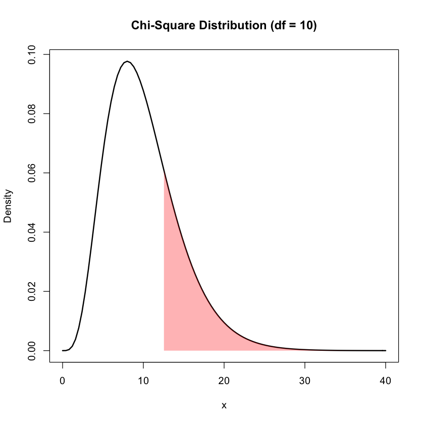

```r
#create density curve
curve(dchisq(x, df = 10), from = 0, to = 40,
main = 'Chi-Square Distribution (df = 10)',
ylab = 'Density',
lwd = 2)

#create vector of x values
x_vector <- seq(12.5488613968894, 40)

#create vector of chi-square density values
p_vector <- dchisq(x_vector, df = 10)

#fill in portion of the density plot from 0 to 40
polygon(c(x_vector, rev(x_vector)), c(p_vector, rep(0, length(p_vector))),
        col = adjustcolor('red', alpha=0.3), border = NA)
```

## Example 2 $\chi^2_{30,0.01}$

- the 30 is the degrees of freedom
- the 0.01 is the percentile, but since we will only get the right side, then it represents the 99th percentile

```r
# examples for the 75th percentile
qchisq(.01, 30, lower.tail=FALSE)
```

50.8921813115171

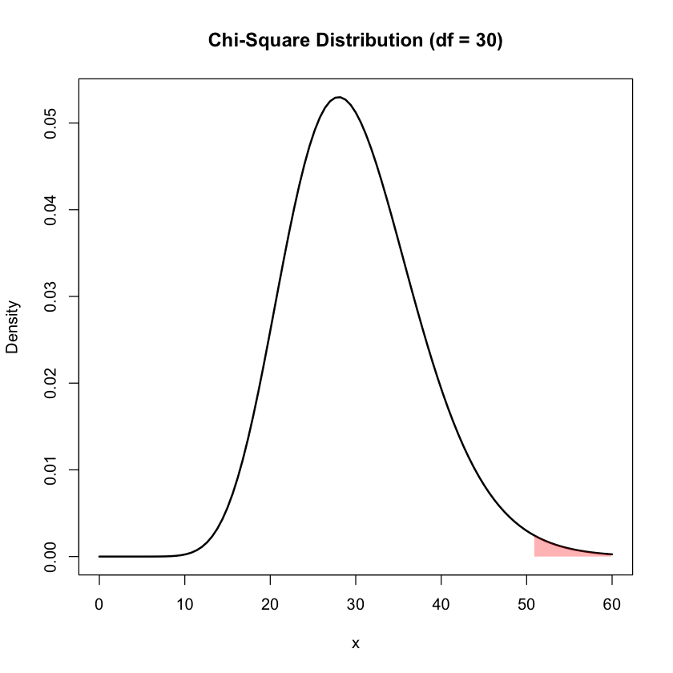

```r
#create density curve
curve(dchisq(x, df = 30), from = 0, to = 60,
main = 'Chi-Square Distribution (df = 30)',
ylab = 'Density',
lwd = 2)

#create vector of x values
x_vector <- seq(50.8921813115171, 60)

#create vector of chi-square density values
p_vector <- dchisq(x_vector, df = 30)

#fill in portion of the density plot from 0 to 40
polygon(c(x_vector, rev(x_vector)), c(p_vector, rep(0, length(p_vector))),
        col = adjustcolor('red', alpha=0.3), border = NA)
```

## Tail Probabilities from the 𝜒2 distribution

- For a given $\chi^2$ value, what is the tail probability/area to the right or left
- For tail probabilities to the right: $P(\chi^2_k > x)$
- For tail probabilities to the left: $P(\chi^2_k < x)$
- `pchisq(x, k, lower.tail=FALSE)`

## Example 3 $P(\chi^2_{15} > 20)$

- the 15 is the degrees of freedom
- the 20 is the given $\chi^2$ value
- since $\chi^2$ is greater than the given $\chi^2$ value, this is a right tail probability

```r
pchisq(20, 15, lower.tail=FALSE)
```

0.171932689376601

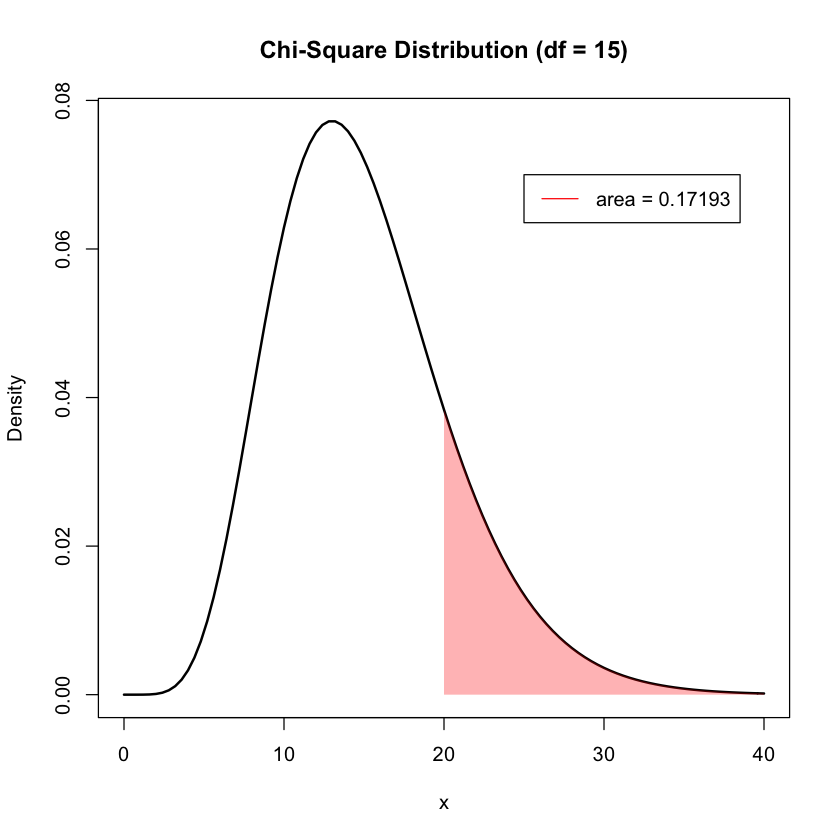

```r
#create density curve
curve(dchisq(x, df = 15), from = 0, to = 40,
main = 'Chi-Square Distribution (df = 15)',
ylab = 'Density',
lwd = 2)

#create vector of x values
x_vector <- seq(20, 40)

#create vector of chi-square density values
p_vector <- dchisq(x_vector, df = 15)

#fill in portion of the density plot from 0 to 40
polygon(c(x_vector, rev(x_vector)), c(p_vector, rep(0, length(p_vector))),
        col = adjustcolor('red', alpha=0.3), border = NA)
legend(x=25, y=0.07, legend=c("area = 0.17193"), lty=1:2, col=c('red'), bg="white")
```

## Role of 𝜒2 distribution

- Involved in estimatees of variability in a population
- Distribution related to sums of squares
- Example, if we have a random independent samples drawn from $N(\mu,\sigma)$ with *n* random variables $X_1,\ X_2,\ ..\ X_n$, then:
- $ Z_j = \frac{X_j - \mu}{\sigma}\ \sim\ N(0,1)$ for j = 1, 2, ... n
- Since all the samples are independent, then the $ Z_j^2\ \ X_j^2$ for for j = 1, 2, ... n
- then we can conclude that each squared standardized value of $X_j$ has a $\chi^2$ distribution with a single dree of freedom and the sum of all the $X_j^2$ random variables has the $X_n^2$ distribution
- $\Sigma_{j=1}^n Z_{j=1}^2$ = $\frac{1}{\sigma^2}\Sigma (X_j - \mu)^2$ ~ $\chi^2_n$
- Expression can be rearranged so that we have the sum of squares: $$\chi^2_{n-1}\ +\ \chi^2_1$$
- The degrees of freedom is n - 1

# Student's t Distribution

**The Basics**

- Distribution that resembles the normal distribution but is a bit shorter and fatter
- This distribution is used when the sample size is small and the population standard deviation is unknown.
- The students t distribution is denoted as: $$T\ =\ \frac{\bar{X} - \mu}{\frac{S}{\sqrt{n}}}$$ where S is the sample standard deviation.
- The shape of the Student's t Distribution has a single peak
- The peak conincides with the mean and median, and are located at 0
- The distribution is symmetric around the peak
- The students t distribution has heavier tails than the normal distribution
- Plot below illustrates that as the df increases, the t distribution begins to resemble a normal distribution.

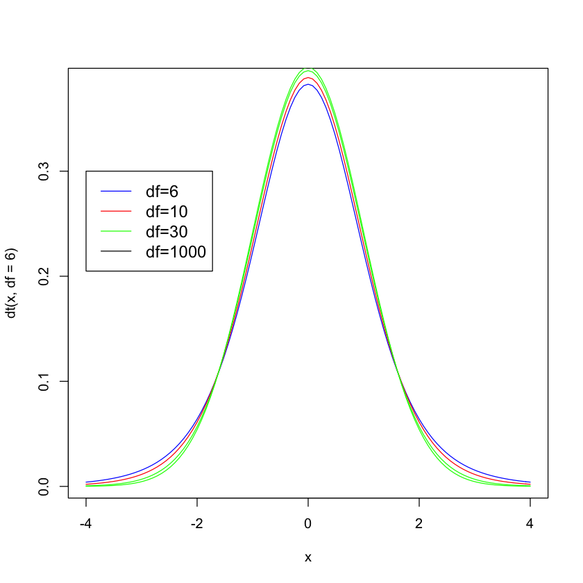

```r
#create density plots
curve(dt(x, df=6), from=-4, to=4, col='blue')
curve(dt(x, df=10), from=-4, to=4, col='red', add=TRUE)
curve(dt(x, df=30), from=-4, to=4, col='green', add=TRUE)
curve(dt(x, df=1000), from=-4, to=4, col='green', add=TRUE)


#add legend
legend(-4, .3, legend=c("df=6", "df=10", "df=30", "df=1000"),
       col=c("blue", "red", "green", "black"), lty=1, cex=1.2)
```

## Quantiles from Student’s t Distribution

- $t_{k,p}$ where k is the degrees of freedom and p is the prescribed upper tail probability
- `qt(p, k, lower.tail=FALSE)`
- In R, this code will denote the quantile that cuts off the probability to the right of the *p*

## Example 4 $t_{15,0.1}$

- the 15 is the degrees of freedom
- the 0.1 is the 90th percentile

```r
qt(0.1, 15, lower.tail=FALSE)
```

1.34060560785046

## Tail Probabilities from the Student's t distribution

- For tail probabilities to the right: $P(t_k > x)$
- For tail probabilities to the left: $P(t_k < x)$
- `pt(x, k, lower.tail=FALSE)`

## Example 5 $P(t_{10} > 1.75)$

- the 10 is the degrees of freedom
- the 1.75 is the t value

```r
pt(1.75, 10, lower.tail=FALSE)
```

0.0553404721329735

# Snedecor’s F Distribution

**The Basics on the F distribution**

- The F distribution is the ratio of two independent random variables with $\chi^2$ distributions drawn from a normal population
- The ratio is F = $\frac{\frac{W}{df_w}}{\frac{V}{df_v}}$
- Unlike the$\chi^2$ and t distribution, the F distribution has two degrees of freedom, expressed as $F_{df_w, df_v}$

```
[1] "probability density for F =  2.5  and degree of freedom =  9  and  10  is  0.09"
```

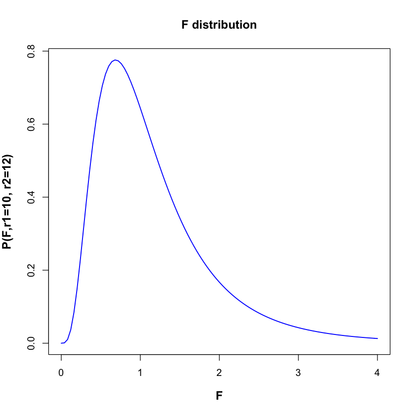

```r
##### Using R library functions for the F distribution

#### probability density function
n1 = 10
n2 = 12
r1 = n1-1
r2 = n2-2
F = 2.5

F_density = df(F, r1, r2)
F_density = round(F_density, digits=2)
print(paste("probability density for F = ", F, " and degree of freedom = ", r1," and ", r2, " is ", F_density))

### Generating the curve of F distribution probability density

x = seq(0,5,0.1)

r1 = 10
r2 = 12

string = "P(F,r1=10, r2=12)"

curve(df(x, r1, r2), xlim=c(0,4), xlab="F", ylab=string, lwd=1.5, cex.lab=1.2, col="blue", main="F distribution", font.lab=2)
```

## Quantiles from F Distribution

- $F_{df_w, df_v}$ where df_w is the degrees of freedom for the numerator and df_v is the degree of freedom of the denominator
- `qf(p, df1, df2, lower.tail=FALSE)`
- In R, this code will denote the quantile that cuts off the probability to the right of the *p*

## Example 6 $F_{5,25, 0.1}$

- the 5 is the degrees of freedom for the numerator
- the 25 is the degrees of freedom for the denominator
- the 0.1 is the 90th percentile

```r
qf(0.1, 5, 25, lower.tail=FALSE)
```

2.09216491108067

## Tail Probabilities from the F distribution

- For tail probabilities to the right: $P(F_{df_w, df_v} > x)$
- For tail probabilities to the left: $P(F_{df_w, df_v} < x)$
- `pf(f, dfw, dfv, lower.tail=FALSE)`

## Example 7 $P(F_{5,25} > 1.66)$

- the 5 is the degrees of freedom for the numerator
- the 25 is the degrees of freedom for the denominator
- the 1.66 is the F value

```r
pf(1.66, 5, 25, lower.tail=FALSE)
```

0.181119683372257

## Example 8 $P(F_{6,13, 0.01})$

- the 6 is the degrees of freedom for the numerator
- the 13 is the degrees of freedom for the denominator
- the 0.01 is the p value at the 99th percentile

```r
qf(0.01, 6, 13, lower.tail=FALSE)
```

4.62036339558485